# A screen-native triage layer for a genome-scale CD4+ T cell Perturb-seq atlas, and the conditions under which it abstains from nominating a target

- Show All Code
- Hide All Code
- View Source

Author

William Guesdon

Published

2026-07-09 23:20

Abstract

Ranking CRISPRi perturbations by suppression of a polyclonal T cell activation program is a standard approach to target nomination. Applied to a genome-scale Perturb-seq atlas of primary human CD4+ T cells, such a ranking returns T cell receptor proximal signalosome genes. We built an exploratory triage layer from measures computed within the screen itself: a single signed efficacy statistic scoring suppression of a 34-gene effector activation module, and a penalty on suppression of a nine-gene activation-induced co-inhibitory transcript module. Of 6,371 perturbations that pass a custom quality-control mask, 263 clear an evidence floor requiring both a minimum number of significantly decreased module genes and net suppression, and 197 additionally fall below the 75th percentile of co-inhibitory suppression, a relative cut that rejects one quarter of the set by construction. Fourteen of the twenty highest ranked perturbations are rejected, against a matched expectation of 4.6 for a shortlist of equal panel-wide effect magnitude (P = 2.0e-4, the smallest value attainable in 5,000 draws, n = 20). A context-selectivity axis carried no information beyond effect magnitude (14 versus 14.2 matched, P = 0.65) and is reported as an annotation. The co-inhibitory module is more suppressed than every one of 200 expression- and induction-matched random modules of the same size, so the module-level permutation probability equals its floor of 1/201; restricting the null to comparably co-regulated modules leaves the observed module above all 50, giving the floor 1/51. The efficacy axis recovers approved immunomodulator targets above chance among the 20 quality-control-eligible curated positives (4 observed, permutation p = 0.0081), while the co-inhibitory criterion adds nothing conditional on the evidence floor (3 observed, 3.00 expected, p = 0.74). Gene set enrichment shows that the efficacy axis inverts IL-2/STAT5 and TNF-alpha/NF-kB signatures relative to a magnitude-matched control, although eleven of the score-defining genes are members of each tested set. In an independent, targeted primary human CD4 CRISPR screen the efficacy axis shows orthogonal concordance under four stratified permutation nulls (Spearman +0.115, n = 471), whereas the co-inhibitory axis does not (Spearman +0.025). Direction of effect could be annotated for 17 of the 197 screen-passing genes; every concordant annotation required an approved loss-of-function-mimicking drug. No novel target met the pre-specified nomination standard, and a pre-registered control on the rebuilt nomination rule fails for want of power. We report the triage layer, the conditions under which it abstains, and the claims withdrawn during the analysis.

# 1 Introduction

Genome-scale Perturb-seq in primary human cells makes it possible to ask which single-gene perturbations move an expression program<sup>1</sup>. The obvious use of such an atlas for therapeutic target identification is to rank perturbations by how strongly they suppress that program. This ranking is a commodity: it requires only the released effect matrix and a gene set.

The approach has a failure mode that its own objective function cannot detect. A perturbation that disables the cell will also collapse an inflammatory signature, and so will a perturbation of a gene required for the receptor-proximal signalling that initiates the program. Ranking on suppression alone does not distinguish a therapeutic window from a defect. The program suppressed here is a polyclonal activation program rather than a signature of any disease, tissue, or patient cohort, so suppression of it is not by itself evidence of therapeutic benefit.

We asked whether a triage layer built only from quantities the screen itself measures can separate the two, and whether such a layer can nominate a target that is not already known. The dataset is a CRISPRi Perturb-seq atlas of primary human CD4+ T cells covering 6,371 rankable perturbations<sup>1</sup>. Because CRISPRi reduces transcript abundance, a nominated gene models an inhibitor, and a nomination is therefore valid only if loss of function is the therapeutic direction.

Three constraints shape what can be claimed. First, the platform is probe-based, so the 10,282 measured genes are a panel and not the transcriptome; effect magnitude is panel-wide. Second, the assay is a 48 h anti-CD3/CD28 restimulation of naive-derived, *ex vivo* expanded conventional CD4 T cells, without polarising cytokines. Third, and most consequentially for interpretation, the co-inhibitory receptors measured here are activation-induced rather than markers of a stable regulatory lineage, and FOXP3 is transiently induced in activated human conventional CD4 T cells without conferring suppressive function<sup>2–4</sup>. We therefore refer throughout to an *activation-induced co-inhibitory module*, and we do not claim to have measured tolerance, regulatory identity, or suppression.

# 2 Methods

## 2.1 Data

We used the released per-perturbation effect matrix `GWCD4i.DE_stats.h5ad` from<sup>1</sup>, a preprint, comprising 33,983 perturbation-by-condition rows across 10,282 measured genes. Raw sequencing data were not reprocessed. Our count of sgRNA library targets is 12,779; the source publication reports 12,748, and the discrepancy is unresolved.

Cells were primary human CD4+ T cells isolated as naive from four donors, activated with a CD3/CD28/CD2 activator, transduced, and expanded *ex vivo* in medium supplemented with 200 IU/ml interleukin-2 throughout. The stimulated arm is a 48 h restimulation; the rest arm is an aliquot of the same expanded cells left without restimulation. The rest arm is therefore not quiescent naive T cells, and no analysis in this manuscript treats it as such.

## 2.2 Quality-control mask

| cumulative filter | library genes remaining | Hart core-essential | Hart nonessential |
| --- | --- | --- | --- |
| in sgRNA library | 12779 | 682 | 141 |
| reaches DE_stats | 11526 | 230 | 135 |
| tested in Stim48hr | 11281 | 196 | 134 |
| + not distal_offtarget | 11154 | 195 | 131 |
| + not neighboring_KD | 10324 | 187 | 131 |
| + ontarget_significant | 6388 | 90 | 3 |
| + not low_target_gex | 6371 | 89 | 3 |

Of 11,281 library genes tested in the 48 h arm, 6,371 survive. The on-target significance requirement removes the largest fraction, and it removes nonessential control genes almost entirely, from 131 to 3. This mask determines which questions can be asked. It conditions on the perturbation having a detectable transcriptional effect, which is a function of both knockdown efficiency and gene essentiality, and it therefore governs the essentiality analysis in Section 3.5. We refer to the surviving perturbations as **quality-control eligible**, not as assay-visible, because visibility is a property of the assay and eligibility is a property of our mask. The mask also excludes perturbations of regulators that the source study validates, among them `LCP2`. Sensitivity analyses under relaxed masks are not reported here and are a limitation (Section 4.1).

## 2.3 Gene modules

The effector module comprises 34 genes induced by stimulation in both of two reference sources, excluding the co-inhibitory genes; 32 are present on the measured panel. The activation-induced co-inhibitory module comprises nine genes: `CTLA4`, `PDCD1`, `LAG3`, `TIGIT`, `FOXP3`, `IKZF2`, `LRRC32`, `IL10` and `TGFB1`. The two modules are disjoint by construction. For each perturbation, the perturbed gene is removed from its own module before scoring, because its on-target knockdown is large, negative, and required to be significant by the mask in Section 2.2.

The effector module is a **polyclonal activation program**. It spans proliferation, cytokine and general activation biology and is not derived from any patient cohort, disease state, tissue signature or indication. No analysis here establishes that suppressing it is therapeutic in any disease.

The co-inhibitory module is not one molecular mechanism. It combines four checkpoint receptors, two transcription factors, two cytokines and `LRRC32`. Two of its members, `TIGIT` and `TGFB1`, do not meet the stimulation-induction criterion applied elsewhere in this analysis. Messenger RNA abundance is not functional checkpoint availability; CTLA-4 function in particular depends on protein trafficking and surface presentation. We therefore call it a **co-inhibitory transcript annotation**, and not a safety, preservation, or therapeutic-window axis.

## 2.4 Triage axes and thresholds

**A single signed efficacy statistic.** Efficacy is the negative mean of the per-gene z statistics of the effector module, so a positive value denotes net suppression. The z statistic is the source study’s default effect estimate and is variance-stabilised across perturbations of differing power. The same statistic is used for ranking, for the evidence floor, for selecting the gene sets tested by enrichment, for drug recovery and for external comparison. An earlier version of this work ranked on the z statistic in one place and scored on the mean log fold change in another. Those two orderings share 9 of their top 20 and 49 of their top 100 (Spearman 0.866). Log-fold-change versions are retained as sensitivity quantities and support no reported inference.

1. **Evidence floor.** A perturbation must significantly decrease at least three effector-module genes at a 10% false discovery rate<sup>5</sup> **and** have a positive efficacy statistic. 263 of 6,371 perturbations pass. The direction requirement is not cosmetic: without it, perturbations that induce the effector module on net while decreasing a few of its genes clear the floor, and one such perturbation was a curated positive.
2. **Co-inhibitory criterion.** Among perturbations clearing the evidence floor, those in the top quartile of co-inhibitory suppression are rejected. 197 remain.

**ImportantThe co-inhibitory cut has no external calibration**

The criterion is a quantile of the evidence-passing set, so approximately one quarter of that set is rejected **by construction**, whatever the shape of the distribution: 197 is 74.9% of 263. The threshold is not calibrated against any adverse phenotype, and the module-level test in Section 3.3 does not estimate an error rate for the classification of any individual gene. The continuous score is the primary quantity; the binary label is a convenience, and “screen-passing” carries no claim of safety.

Viability is reported as a tier rather than used as a rejection, because depletion only under stimulation is an antiproliferative signature shared by an approved drug in this set. Immune-essentiality annotation is reported and never gated on (Section 3.5).

A third axis, context selectivity, required the stimulated effect to exceed the resting effect tenfold. It was evaluated against a magnitude-matched control (Section 3.2), carried no information beyond effect magnitude, and is reported as an annotation.

## 2.5 Statistical inference

Enrichment of the naive ranking against a background is tested with the van Elteren stratified rank-sum test<sup>6</sup> and, for binary flags, the Cochran-Mantel-Haenszel procedure<sup>7</sup>. Both use every control row and draw no random numbers. Strata are deciles of panel-wide effect magnitude. An earlier version of this analysis sampled a single 100-row matched background; that procedure made the p-value a random variable, and 22.4% of seeds returned a non-significant result. It is superseded.

Panel-wide effect magnitude, written $z_{L2}$, is the Euclidean norm of a perturbation’s vector of per-gene z statistics across all 10,282 measured genes. Matching on $z_{L2}$ means matching on deciles of this quantity.

Specificity of a shortlist is assessed by drawing 5,000 shortlists of equal size from the same evidence-passing pool, matched on $z_{L2}$ decile. Monte Carlo probabilities are computed as $(1 + \#\{{\rm null} \ge {\rm observed}\}) / (1 + n_{\rm draws})$. With 5,000 draws the smallest attainable value is $1/5001 = 2.0\times10^{-4}$, and a value equal to that floor means no draw reached the observed statistic. An earlier version of this analysis omitted the correction and reported $P < 0.0001$, which those draws cannot establish.

**Status of the inference.** The thresholds and modules were fixed before the analyses that used them, but the axes themselves, the score, and the nomination rule were developed and revised on this dataset. The probabilities reported here are therefore exploratory. Confirmation would require an untouched dataset, a held-out donor partition, or a rule specified before the data were seen.

## 2.6 External resources

Core-essential (CEGv2) and nonessential (NEGv1) reference gene sets are from<sup>8</sup>. Loss-of-function constraint metrics, LOEUF and pRec, are from gnomAD v4<sup>9</sup>. Tissue expression breadth is from the Human Protein Atlas<sup>10</sup>. Target-disease genetic association, tractability and drug mechanism-of-action annotations are from the Open Targets Platform, release 26.06<sup>11</sup>.

The CRISPRa and CRISPRi screens of<sup>15</sup> are held out. They are used only to validate the efficacy axis out of sample and are never used as a score, a filter, or a threshold.

## 2.7 Gene set enrichment

Preranked gene set enrichment analysis<sup>16</sup> was run with `gseapy`<sup>17</sup> against the MSigDB Hallmark collection<sup>18</sup>, on the 48 h stimulated panel-wide z statistic. The background is the measured panel by construction. The comparison set is a group of perturbations matched on panel-wide effect magnitude.

## 2.8 Nomination rule and its calibration

A nomination rule was selected by its sensitivity on the positive class, that is, the fraction of the 5 approved-drug targets recovered by the pipeline that the rule would re-nominate had their drug status not been known. This criterion never inspects which novel gene a rule promotes. The rule may not read any field derived from approved-drug status; a permutation test asserts at run time that no such field can change the nominated set.

## 2.9 Software and reproducibility

Analyses are Python 3.13 with `numpy`, `pandas`, `scipy` and `gseapy`. Every number in this manuscript is read at render time from a table under `results/tables/`. Two scripts fail with a non-zero exit code if any quoted value has drifted from its source (Section 6.1), and several analysis scripts exit non-zero if a pre-registered control fails.

# 3 Results

## 3.1 Perturbations ranked by effector-program suppression

Ranking the 6,371 perturbations by effector-module suppression returns receptor-proximal signalling genes. Of the twenty highest ranked perturbations, the triage layer rejects 14. An independent CRISPRi screen with a protein-level readout<sup>15</sup> confirms that several of these knockdowns do reduce IL-2 production, so they are effective by an external measure while being refused here.

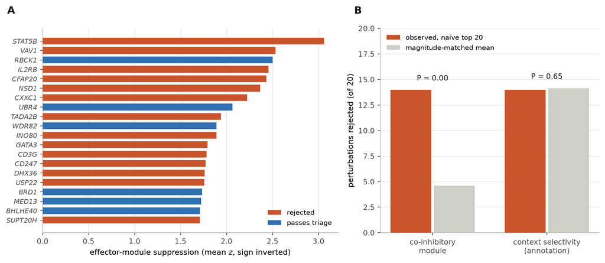

Figure 1: Effector-program suppression and triage outcome. **A.** The twenty perturbations with the highest effector-suppression score, ordered by rank. Bars are coloured by triage outcome. **B.** Rejection counts among those twenty, by axis, against the mean count in 5,000 shortlists of twenty perturbations drawn from the same evidence-passing pool and matched on panel-wide effect magnitude. Rejection on the co-inhibitory axis exceeds the matched expectation; the context-selectivity annotation does not. Error bars are omitted because the matched values are means of the null distribution, and the exact permutation probabilities are printed above each pair.

```python
w = window.copy()
w["naive_rank"] = (-w["eff_mean_z"]).rank(ascending=False, method="first")
top20 = w.nsmallest(20, "naive_rank").sort_values("naive_rank")

fig, (axa, axb) = plt.subplots(1, 2, figsize=(10, 4.4), gridspec_kw={"width_ratios": [1.35, 1]})

axis_style(axa, xgrid=True, ygrid=False)
colours = [PALETTE["blue"] if s else PALETTE["vermillion"] for s in top20["safe"]]
y = np.arange(len(top20))
axa.barh(y, -top20["eff_mean_z"], color=colours, edgecolor="none", height=0.72, zorder=3)
axa.set_yticks(y)
axa.set_yticklabels(top20["gene_name"], fontsize=8, style="italic")
axa.invert_yaxis()
axa.set_xlabel("effector-module suppression (mean $z$, sign inverted)", fontsize=9)
axa.legend(handles=[mpl.patches.Patch(facecolor=PALETTE["vermillion"], label="rejected"),
                    mpl.patches.Patch(facecolor=PALETTE["blue"], label="passes triage")],
           loc="lower right", frameon=False, fontsize=8)
panel_label(axa, "A")

axis_style(axb)
labels = ["co-inhibitory\nmodule", "context selectivity\n(annotation)"]
obs = [int(TOL["observed"]), int(SEL["observed"])]
exp = [float(TOL["matched_mean"]), float(SEL["matched_mean"])]
pvals = [float(TOL["p_matched_ge_observed"]), float(SEL["p_matched_ge_observed"])]
x = np.arange(2)
axb.bar(x - 0.19, obs, width=0.36, color=PALETTE["vermillion"], zorder=3, label="observed, naive top 20")
axb.bar(x + 0.19, exp, width=0.36, color=PALETTE["grey"], zorder=3, label="magnitude-matched mean")
for i, (o, e, p) in enumerate(zip(obs, exp, pvals)):
    txt = "P < 0.0001" if p < 1e-4 else f"P = {p:.2f}"
    axb.text(i, max(o, e) + 0.9, txt, ha="center", fontsize=8.5, color=PALETTE["ink"])
axb.set_xticks(x)
axb.set_xticklabels(labels, fontsize=8.5)
axb.set_ylabel("perturbations rejected (of 20)", fontsize=9)
axb.set_ylim(0, 20)
axb.legend(loc="upper left", frameon=False, fontsize=8)
panel_label(axb, "B")

fig.tight_layout()
plt.show()
```

## 3.2 Specificity of the co-inhibitory axis relative to effect magnitude

A shortlist of twenty perturbations drawn from the same evidence-passing pool and matched on $z_{L2}$ decile is rejected on the co-inhibitory axis 4.6 times, against 14 observed. No matched shortlist reached the observed count, so P = 2.0e-04, the floor for 5,000 draws (n = 20). The context-selectivity annotation flags 14 of the same twenty against 14.2 matched (P = 0.65). Selectivity therefore carries no information beyond effect magnitude and is reported as an annotation.

An earlier formulation counted rejections on any axis and reported 18 of 20 against a matched expectation of 15.3 (P = 0.104). That statement is withdrawn: the aggregate count was substantially attributable to effect magnitude, and the axis-resolved comparison above supersedes it.

Against a background stratified on panel-wide effect magnitude, using every control row, co-inhibitory suppression in the naive top 100 exceeds the background by a one-sided van Elteren z of 11.10 (p = 6.3e-29). This is a perturbation-level association and is not a module-level inference; see Section 3.3.

## 3.3 Module-level inference and the effective unit of analysis

Both modules are stimulation-induced, so any perturbation that blunts activation reduces both. The test that separates them holds the perturbation set fixed at the 100 highest-efficacy perturbations and varies the module. If co-inhibitory suppression reflected activation amplitude alone, a random nine-gene module matched on expression and on induction would fall equally far.

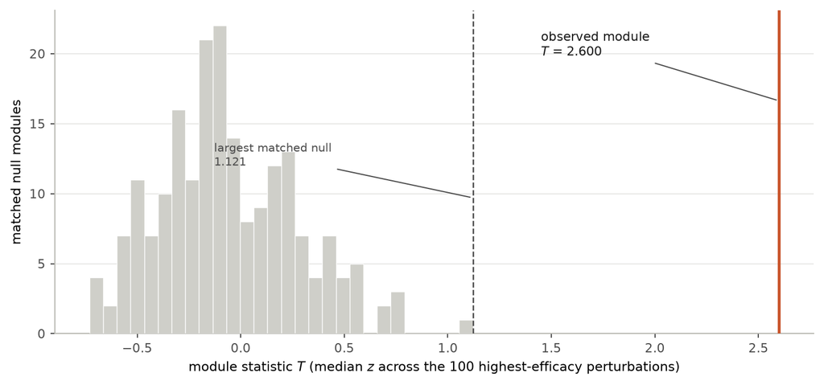

Figure 2: Module-level null. Distribution of the module statistic $T$, the median $z$ of a nine-gene module across the 100 highest-efficacy perturbations, for 200 random modules matched on expression and on stimulation induction (grey). The perturbation set is held fixed, so activation amplitude is constant across the null. The observed value for the activation-induced co-inhibitory module (vermillion) exceeds every matched module. Restricting the null pool to modules of comparable internal co-regulation raises the permutation probability from 0.005 to 0.0196; the latter is the value reported in this manuscript. The positive control, the effector module itself, lies far to the right and is not drawn.

```python
fig, ax = plt.subplots(figsize=(8, 3.8))
axis_style(ax)
ax.hist(nulls["T_null"], bins=28, color=PALETTE["grey"], edgecolor="white", linewidth=0.5, zorder=3)
ax.axvline(float(n9["T_real"]), color=PALETTE["vermillion"], linewidth=2, zorder=4)
ax.axvline(float(n9["T_null_max"]), color=PALETTE["ink2"], linewidth=1, linestyle="--", zorder=4)
ax.annotate(f"observed module\n$T$ = {n9['T_real']:.3f}",
            xy=(float(n9["T_real"]), ax.get_ylim()[1] * 0.72),
            xytext=(float(n9["T_real"]) - 1.15, ax.get_ylim()[1] * 0.86),
            fontsize=8.5, color=PALETTE["ink"],
            arrowprops=dict(arrowstyle="-", color=PALETTE["ink2"], linewidth=0.8))
ax.annotate(f"largest matched null\n{n9['T_null_max']:.3f}",
            xy=(float(n9["T_null_max"]), ax.get_ylim()[1] * 0.42),
            xytext=(float(n9["T_null_max"]) - 1.25, ax.get_ylim()[1] * 0.52),
            fontsize=8, color=PALETTE["ink2"],
            arrowprops=dict(arrowstyle="-", color=PALETTE["ink2"], linewidth=0.8))
ax.set_xlabel("module statistic $T$ (median $z$ across the 100 highest-efficacy perturbations)", fontsize=9)
ax.set_ylabel("matched null modules", fontsize=9)
fig.tight_layout()
plt.show()
```

The observed statistic is 2.600. The largest of the 200 matched null modules reaches 1.121, and the median null is -0.114. Because no null module reaches the observed value, the module-level permutation probability equals its floor, 0.004975 = 1/201. It is a bound, not an estimate. Co-induction accounts for 34% of the effect reported by an expression-matched null that did not control for induction. The negative control, the false-positive rate on random modules, is 0.045 against a nominal 5%.

One confound is not closed, and the restricted null does not close it. The nine module genes are co-regulated, and across the null modules the mean gene-gene correlation predicts the statistic (Spearman +0.206, p = 0.0035). The observed module’s mean correlation, 0.1046, exceeds that of **every** null module (largest 0.0867). Restricting the null pool to its most co-regulated quartile leaves 50 modules, the observed module still exceeds all of them, and the resulting probability is again the floor, 0.0196 = 1/51. Restriction to a quartile therefore does not make the observed module exchangeable with the null: it remains more internally correlated than any module the null can supply. The correct reading is that this confound is open, not that it has been controlled and the evidence merely attenuated.

## 3.5 Selection effects on essentiality and immune-deficiency annotations

Two annotation-based axes were evaluated as candidate safety filters and both were rejected.

Cancer-cell essentiality cannot be assessed in this screen, because essentiality determines whether a perturbation enters the analysable set. Of the core-essential genes in the sgRNA library, only a minority reach the differential expression table, since their knockdown removes the cell; a subsequent on-target significance filter then removes most nonessential controls. Among the survivors of this double selection, 89 rankable core-essential genes have a median naive rank of 2070 against 3198 for the remainder (Mann-Whitney two-sided p = 0.0023). A previously reported figure of 31 rankable essentials at median rank 3,148 with p = 0.611 is withdrawn; it derived from a gene-symbol vocabulary error. Neither the withdrawn value nor its replacement supports a causal inference, because the comparison is made among the survivors of a selection on the exposure.

Immune-essentiality, taken from a curated inborn-errors-of-immunity list, is more enriched among approved immunomodulator drug targets than among the highest-ranked perturbations. It is therefore reported as an annotation and never used as a filter.

## 3.6 Recovery of approved immunomodulator targets

Of 36 curated approved-immunomodulator targets, 20 are quality-control eligible (Section 2.2). The remainder are excluded by the assay or by the mask: the stimulation carries no polarising cytokines, so cytokine-signalling targets rank near the bottom, and two targets of an approved JAK inhibitor were never perturbed. Recall is bounded by the assay and the mask, not by the ranking.

The positive set is not a set of independent genes. It contains correlated mechanism units, including three calcineurin subunits, two IMPDH paralogues, two IKZF paralogues and three CD3 chains. A gene-level permutation treats each as an independent recovery and therefore overstates the evidence. Collapsing the positives into drug-mechanism units is not done here and is a limitation (Section 4.1).

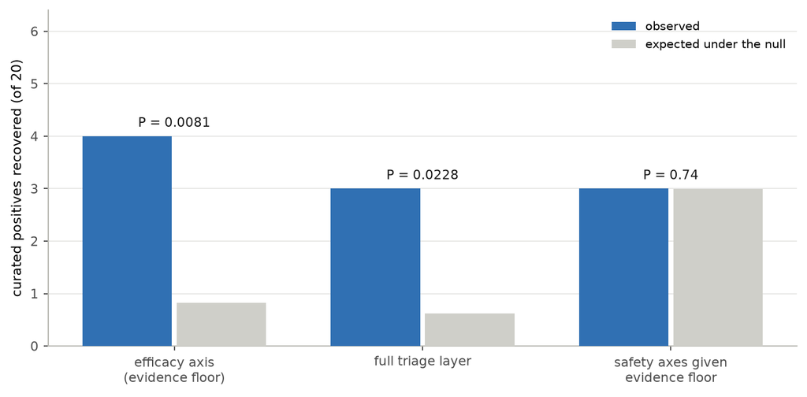

Figure 3: Recovery of approved immunomodulator targets among the 20 assay-visible curated positives. Observed counts against the expectation under a 50,000-draw permutation null over the screened-gene background. The efficacy axis recovers more positives than chance. The safety axes, evaluated conditional on the evidence floor, add nothing beyond it, which is the expected behaviour of a safety criterion. Permutation probabilities are printed above each pair; the third comparison has no permutation probability because it is conditional and is reported by its hypergeometric probability.

```python
rows = ["positives pass evidence floor", "positives pass full gate", "safety enriches given evidence"]
short = ["efficacy axis\n(evidence floor)", "full triage layer", "safety axes given\nevidence floor"]
obs = [float(recovery.loc[r, "observed"]) for r in rows]
exp = [float(recovery.loc[r, "expected"]) for r in rows]
pv = [recovery.loc[r, "perm_p"] for r in rows]
hp = [recovery.loc[r, "hyper_p"] for r in rows]

fig, ax = plt.subplots(figsize=(7.6, 3.8))
axis_style(ax)
x = np.arange(3)
ax.bar(x - 0.19, obs, width=0.36, color=PALETTE["blue"], zorder=3, label="observed")
ax.bar(x + 0.19, exp, width=0.36, color=PALETTE["grey"], zorder=3, label="expected under the null")
for i in range(3):
    label = f"P = {pv[i]:.4f}" if pd.notna(pv[i]) else f"P = {hp[i]:.2f}"
    ax.text(i, max(obs[i], exp[i]) + 0.18, label, ha="center", fontsize=8.5, color=PALETTE["ink"])
ax.set_xticks(x)
ax.set_xticklabels(short, fontsize=8.5)
ax.set_ylabel("curated positives recovered (of 20)", fontsize=9)
ax.set_ylim(0, 6.4)
ax.legend(frameon=False, fontsize=8, loc="upper right")
fig.tight_layout()
plt.show()
```

The efficacy axis recovers 4 of the 20 assay-visible positives against 0.83 expected (permutation p = 0.0081, 50,000 draws). The full triage layer recovers 3 (p = 0.0228). Conditional on the evidence floor, the safety axes recover 3 against 3.00 expected (p = 0.74). Recovery is therefore attributable to the evidence floor. We do not read the absence of enrichment as evidence of safety. Approved status is not a safety label, and a null result on a three-gene contingency is not evidence of anything. This comparison provides limited support for the binary evidence floor and none for the co-inhibitory criterion.

Rank discrimination on the same positives is absent. Computed on the primary efficacy statistic, the area under the receiver operating characteristic curve is 0.497 with a 95% bootstrap interval of [0.339, 0.656], which contains chance. Out-of-sample validation of the efficacy axis is instead provided by the held-out screen of<sup>15</sup>, where it attains 0.701 [0.583, 0.803] against 33 IL-2-reducing hits. Schmidt’s hits are the receptor-proximal signalosome that the triage layer rejects, so a triage score that beat the efficacy axis on this set would be suspect rather than reassuring.

Both curves were previously reported as 0.542 [0.373, 0.707] and 0.702 [0.591, 0.814]. Those values were computed on a third score, distinct from the primary statistic and from the one used elsewhere. They are withdrawn.

A drug-recovery benchmark constructed from Open Targets<sup>11</sup> cannot be powered on this dataset. Against a threshold of 60 positives fixed before counting, the primary count is 38 and the most permissive upper bound is 53. This is a property of the perturbation library rather than of the ranking. An initial count of 173 was inflated by three annotation artifacts: haematological malignancies classified under immune system disorder; mechanism-of-action records naming every subunit of a protein complex; and a maximum clinical stage computed across all indications rather than per indication.

## 3.7 Mechanistic specificity by gene set enrichment

The efficacy axis could suppress an activation program specifically, or it could move many genes. These are distinguished by comparing the highest-efficacy perturbations against a set matched on panel-wide effect magnitude.

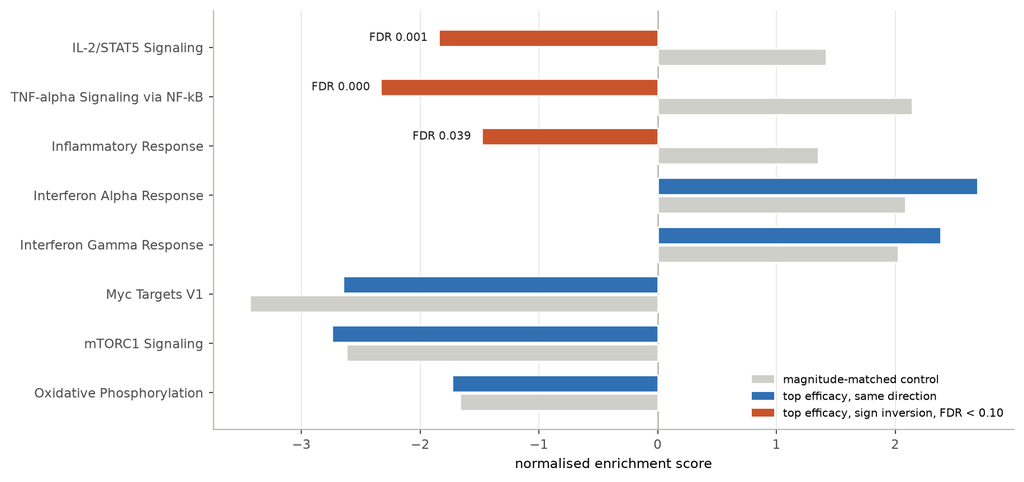

```python
top = gsea[gsea["group"] == "top_efficacy"].set_index("Term")
ctl = gsea[gsea["group"] == "magnitude_control"].set_index("Term")
HALL = ["IL-2/STAT5 Signaling", "TNF-alpha Signaling via NF-kB", "Inflammatory Response",
        "Interferon Alpha Response", "Interferon Gamma Response",
        "Myc Targets V1", "mTORC1 Signaling", "Oxidative Phosphorylation"]
missing = set(HALL) - set(top.index)
if missing:
    raise KeyError(f"gsea_hallmark.csv is missing {missing}")

nes_t = np.array([top.loc[t, "NES"] for t in HALL])
nes_c = np.array([ctl.loc[t, "NES"] for t in HALL])
fdr_t = np.array([top.loc[t, "FDR q-val"] for t in HALL])
flip, sig = (nes_t < 0) & (nes_c > 0), fdr_t < 0.10
y = np.arange(len(HALL))

fig, ax = plt.subplots(figsize=(9.6, 4.6))
axis_style(ax, xgrid=True, ygrid=False)
ax.axvline(0, color=PALETTE["axis"], linewidth=1)
ax.barh(y + 0.19, nes_c, height=0.34, color=PALETTE["grey"], edgecolor="white", zorder=3)
ax.barh(y - 0.19, nes_t, height=0.34, edgecolor="white", zorder=3,
        color=[PALETTE["vermillion"] if (f and s) else PALETTE["blue"] for f, s in zip(flip, sig)])
for i in np.where(flip)[0]:
    note = f"FDR {fdr_t[i]:.3f}" + ("" if sig[i] else " (n.s.)")
    ax.text(nes_t[i] - 0.09, i - 0.19, note, ha="right", va="center", fontsize=7.5,
            color=PALETTE["ink"] if sig[i] else PALETTE["muted"])
ax.set_yticks(y)
ax.set_yticklabels(HALL, fontsize=8.5)
ax.invert_yaxis()
ax.set_xlabel("normalised enrichment score", fontsize=9)
ax.legend(handles=[mpl.patches.Patch(facecolor=PALETTE["grey"], label="magnitude-matched control"),
                   mpl.patches.Patch(facecolor=PALETTE["blue"], label="top efficacy, same direction"),
                   mpl.patches.Patch(facecolor=PALETTE["vermillion"], label="top efficacy, sign inversion, FDR < 0.10")],
          loc="lower right", frameon=False, fontsize=7.5)
fig.tight_layout()
plt.show()
```

**WarningThe enrichment test is partly circular**

Eleven of the 34 effector-module genes that define the efficacy score are members of the tested `IL-2/STAT5 Signaling` set, and eleven are members of `TNF-alpha Signaling via NF-kB`. Those genes remain in the ranked lists. The reported false discovery rates also test enrichment within each aggregated ranked list separately; they do not test whether enrichment differs between the top-efficacy group and the matched control. A non-circular version would remove the score-defining genes from both the ranked lists and the tested sets, use repeated matched controls, and test the difference in enrichment directly by permutation over perturbations. That analysis is not reported here (Section 4.1).

IL-2/STAT5 signalling reaches a normalised enrichment score of -1.845 (FDR 0.001) in the top-efficacy set and +1.418 in the magnitude-matched control. TNF-alpha signalling via NF-kB reaches -2.330 against +2.142. Myc targets are suppressed to -2.65 and -3.44 respectively, indistinguishably. The specificity is an inversion of the immune signatures at equal effect magnitude, not a larger effect.

## 3.8 Sensitivity of the nomination rule on recovered drug targets

The pipeline recovers 5 approved-drug targets among the 197 screen-passing genes. Applying a candidate nomination rule to those targets, and asking how many it would re-nominate if their drug status were unknown, calibrates the rule without reference to any novel gene.

[output not shown]

Selecting instead the most restrictive rule whose positive-class sensitivity is complete gives the screen gate combined with structural tractability and the exclusion of direction-discordant genes. It returns 85 candidates.

**ImportantA pre-registered control on this rule fails**

The rule was rebuilt after the initial result was known. It is exploratory model repair, transparently logged, and its controls are sanity checks rather than confirmatory statistics. One of those checks now fails.

Clinical precedent, meaning that a drug against the gene has reached the clinic, is reported and never used as a criterion. It is true of 32 of the 36 curated positives, so a rule reading it would recover approved drug targets by construction.

## 3.9 Availability of direction-of-effect annotation

Because CRISPRi models an inhibitor, a nomination requires that loss of function be the therapeutic direction. These are **manually assigned annotations, not adjudicated measurements**. An annotation was available for 17 of the 197 screen-passing genes; 180 have none.

| basis | genes |
| --- | --- |
| no direction annotation available | 180 |
| approved LoF-mimicking drug (OT actionType) | 15 |
| manually curated negative regulator (not adjudicated) | 2 |

Two earlier rules were withdrawn. The set of action types treated as loss-of-function-mimicking included `BINDING AGENT` and `CROSS-LINKING AGENT`; neither implies reduced target activity, and the anti-CD3 and anti-CD28 reagents that stimulate the cells in this screen are cross-linking agonists. A second rule inferred concordance from an inborn error of immunity, on the reasoning that a gene whose loss impairs immunity must promote it. That inference is unsafe. `PTEN` is an inborn-error gene whose loss dysregulates PI3K signalling and produces lymphoid hyperplasia and autoimmunity, and the rule called it concordant. Immunodeficiency and autoimmunity are not opposite ends of one axis. `PTEN` is now unannotated.

What remains is asymmetric. Every concordant annotation requires an approved drug whose mechanism mimics loss of function, so the conditional probability of a concordant annotation given a gene with no approved drug is zero and the missingness is not at random. The two discordant annotations come from a hand-curated list of canonical negative regulators, which is a judgement rather than a measurement. Direction can exclude a candidate; it cannot promote one. Excluding the two discordant genes licenses no direction-safety claim about the remaining 180.

`PTPN2` illustrates the consequence. It has strong autoimmune genetic support<sup>20</sup> and would be promoted by a genetics-weighted ranking, but it is a negative regulator of T cell receptor signalling whose loss causes autoimmunity in mice<sup>21</sup> and, in patients with germline heterozygous loss-of-function variants, early-onset systemic autoimmunity<sup>22</sup>. A knockdown screen models the wrong direction for this gene. Human genetic support is direction-agnostic and is a prior on success rather than a sufficient condition<sup>23–25</sup>.

Attempts to obtain direction from data that are not characterisation-bound failed for reasons specific to each instrument. Colocalisation of autoimmune GWAS signals with expression quantitative trait loci was calibrated on a nine-gene panel of known direction and gated to apply only at an accuracy of 0.80; it attained 0.50 and was not applied. The reason is principled: an expression QTL measures transcript abundance, whereas the protective `TYK2` P1104A allele is a coding hypomorph with near-normal expression<sup>26</sup>.

## 3.10 External replication in an independent primary human CD4 screen

<sup>12</sup> provides signed, protein-level readouts in primary human CD4 T cells for IL-2, the activation output that the efficacy axis scores, and for CTLA-4, one of the nine genes in the co-inhibitory module. It is a **targeted** screen of approximately 1,350 transcription factors and chromatin modifiers, not a genome-wide replication cohort, and it shares that library exactly with<sup>13</sup> (Jaccard index 1.0000). We therefore describe the comparison below as orthogonal concordance rather than replication.

| hypothesis | n | Spearman | permutation null stratified on | P | verdict |
| --- | --- | --- | --- | --- | --- |
| H1 co-inhibitory attrition -> CTLA-4 loss | 471 | 0.025 | z_L2 | 0.6187 | DOES NOT REPLICATE |
| H1 co-inhibitory attrition -> CTLA-4 loss | 471 | 0.025 | resting-arm disruption | 0.6172 | DOES NOT REPLICATE |
| H1 co-inhibitory attrition -> CTLA-4 loss | 471 | 0.025 | stimulated-arm DE burden | 0.6062 | DOES NOT REPLICATE |
| H1 co-inhibitory attrition -> CTLA-4 loss | 471 | 0.025 | z_L2 and resting-arm disruption jointly | 0.5892 | DOES NOT REPLICATE |
| H2 efficacy -> IL-2 loss | 471 | 0.115 | z_L2 | 0.0235 | REPLICATES |
| H2 efficacy -> IL-2 loss | 471 | 0.115 | resting-arm disruption | 0.0205 | REPLICATES |
| H2 efficacy -> IL-2 loss | 471 | 0.115 | stimulated-arm DE burden | 0.021 | REPLICATES |
| H2 efficacy -> IL-2 loss | 471 | 0.115 | z_L2 and resting-arm disruption jointly | 0.0205 | REPLICATES |

The efficacy axis is associated with IL-2 loss (Spearman +0.115, n = 471), and the association persists after coarse stratification on all four covariates, including resting-arm transcriptional disruption. The effect is small. The co-inhibitory axis is not associated with CTLA-4 loss (Spearman +0.025) under any stratification.

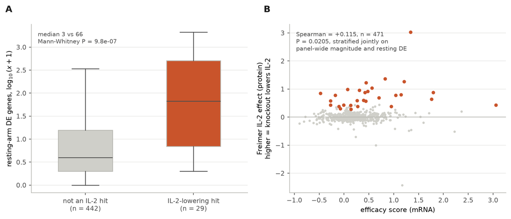

Figure 5: External comparison with the independent primary human CD4 CRISPR screen of Freimer et al. **A.** Genes whose knockout significantly lowers IL-2 carry far more resting-arm differential expression than genes that do not, so a thresholded IL-2 hit call partly reports impaired transcription of an induced gene rather than specific immunosuppression. **B.** The continuous association between the mRNA efficacy score and the signed protein-level IL-2 effect survives a permutation null stratified jointly on panel-wide effect magnitude and resting-arm differential expression. The continuous axis replicates; the thresholded hit call, which a promotion rule would use, does not. Grey, non-hits; vermillion, IL-2-lowering hits.

```python
fh = fdata[fdata["freimer_il2_lowers"]]
fn = fdata[~fdata["freimer_il2_lowers"]]
p_joint = float(rev["h2_p_stratified_jointly"])

fig, (axa, axb) = plt.subplots(1, 2, figsize=(9.6, 4.2))

axis_style(axa)
bp = axa.boxplot([np.log10(fn["rest_de_genes"] + 1), np.log10(fh["rest_de_genes"] + 1)],
                 patch_artist=True, widths=0.5, showfliers=False, zorder=3)
for patch, colour in zip(bp["boxes"], [PALETTE["grey"], PALETTE["vermillion"]]):
    patch.set_facecolor(colour)
    patch.set_edgecolor(PALETTE["axis"])
for part in ("whiskers", "caps", "medians"):
    for element in bp[part]:
        element.set_color(PALETTE["ink2"])
axa.set_xticklabels([f"not an IL-2 hit\n(n = {len(fn)})", f"IL-2-lowering hit\n(n = {len(fh)})"], fontsize=8.5)
axa.set_ylabel("resting-arm DE genes, $\\log_{10}(x+1)$", fontsize=9)
axa.text(0.03, 0.96, f"median {fn['rest_de_genes'].median():.0f} vs {fh['rest_de_genes'].median():.0f}\n"
                     f"Mann-Whitney P = {rev['mwu_p_hits_more_resting_disruption']:.1e}",
         transform=axa.transAxes, fontsize=8, color=PALETTE["ink2"], va="top")
panel_label(axa, "A")

axis_style(axb)
axb.scatter(fn["efficacy"], fn["freimer_il2_lfc"], s=10, color=PALETTE["grey"], zorder=2, linewidths=0)
axb.scatter(fh["efficacy"], fh["freimer_il2_lfc"], s=22, color=PALETTE["vermillion"], zorder=3, linewidths=0)
axb.axhline(0, color=PALETTE["axis"], linewidth=0.9)
axb.set_xlabel("efficacy score (mRNA)", fontsize=9)
axb.set_ylabel("Freimer IL-2 effect (protein)\nhigher = knockout lowers IL-2", fontsize=9)
axb.text(0.03, 0.96, f"Spearman = {float(H2['rho'].iloc[0]):+.3f}, n = {len(fdata)}\n"
                     f"P = {p_joint:.4f}, stratified jointly on\npanel-wide magnitude and resting DE",
         transform=axb.transAxes, fontsize=8, color=PALETTE["ink2"], va="top")
panel_label(axb, "B")

fig.tight_layout()
plt.show()
```

The thresholded hit call is confounded. The 29 genes called IL-2-lowering carry a median of 66 resting-arm differentially expressed genes, against 3 for the 442 remaining genes (Mann-Whitney P = 9.8e-07). IL-2 is a highly induced transcript, so a perturbation that impairs transcription broadly will lower it. The continuous association persists after coarse stratification on that confound; the hit call does not, and a promotion rule uses the hit call.

## 3.11 Exploratory relaxation of the promotion rule

Restricted to the 85-gene nomination pool and to a pre-declared coverage requirement of ten co-tested genes, no candidate could be assessed: only six pool genes are co-tested in the IL-2 arm. A subsequent exploratory relaxation removed the coverage requirement and promoted genes whose knockout significantly lowers IL-2. It returned two genes, ATXN7L3 and XBP1.

Both fail criteria specified earlier in this manuscript. Measured in this screen, `ATXN7L3` lies at the 96.2nd percentile of resting-arm differential expression and has a stimulated-over-resting ratio of 0.92, against the pre-specified tenfold context-selectivity criterion; a ratio below one means the perturbation disturbs the unstimulated cell more than the stimulated cell. `XBP1` lies at the 92.1st percentile. Neither carries autoimmune genetic support, a small-molecule binding pocket, or clinical precedent. Neither shows CTLA-4 lowering, which is the absence of a liability signal and not evidence of preservation.

The comparator library is a panel of transcription factors and chromatin modifiers, so the co-tested gene set is enriched for transcriptional and chromatin machinery by construction. Both promoted genes are drawn from that enrichment, and neither result should be read as a statement about T cell biology.

# 4 Discussion

We built a triage layer for a genome-scale CD4+ T cell Perturb-seq atlas from quantities the screen measures, and we report the conditions under which it declines to nominate.

Three of its properties are supported. Ranking by effector-program suppression returns perturbations that an independent protein-level screen confirms are effective and that this layer refuses, and the refusal is specific to the co-inhibitory axis rather than to effect magnitude. The efficacy axis suppresses IL-2/STAT5 and TNF-alpha/NF-kB signatures where an equal-magnitude control does not, and it replicates on an independent, protein-level, primary human CD4 screen under four stratified nulls. It recovers approved immunomodulator targets above chance among the assay-visible positives, while the safety axes add nothing beyond it, which is the behaviour a safety criterion should show.

Several properties are not supported, and we state them before any conclusion that rests on the layer.

The co-inhibitory module is an interpretation. In a 48 h stimulation of bulk primary human conventional CD4 T cells, its receptors are activation-induced, and FOXP3 is transiently induced without conferring suppressive function<sup>2–4</sup>. We measured messenger RNA. We did not measure tolerance, regulatory identity, suppression, or a clinical outcome.

The binding constraint on nomination is not the ranking method. It is the absence of a direction-of- effect measurement for 180 of the 197 screen-passing genes, and the fact that the annotations which do carry direction are available only for genes that a drug or a monogenic syndrome has already characterised. Direction can exclude; it cannot promote. Instruments that are not characterisation-bound failed for reasons intrinsic to each: an expression QTL reports abundance rather than activity<sup>26</sup>; and the comparator screens, although functional and signed, use a targeted transcription-factor and chromatin-modifier library<sup>12,13</sup> whose intersection with a genome-scale screen is small and non-random.

Recall is bounded by the assay. Stimulation through the T cell receptor without polarising cytokines places cytokine-signalling targets near the bottom of the ranking, and single-gene CRISPRi cannot see a redundant target: the two catalytic calcineurin paralogues each yield fewer than four differentially expressed genes, whereas the non-redundant regulatory subunit yields 523. A drug-recovery benchmark built on this dataset is underpowered by a factor of roughly two against a threshold fixed in advance, and this is a property of the perturbation library rather than of the method.

No gene met the pre-specified nomination standard, and the pre-registered control on the rebuilt nomination rule fails for want of power. We regard abstention as the correct output of the layer given the available evidence, rather than as a limitation of the screen. Resolving it requires an instrument that is signed, functional, primary-human-CD4, and genome-wide. None of the three we evaluated satisfies all four conditions simultaneously.

## 4.1 Limitations

The work is an exploratory computational reanalysis. It is not a validated method for target discovery, safety assessment, or therapeutic-window estimation, and the following are known deficiencies rather than hypothetical ones.

**The co-inhibitory criterion is a transcript annotation.** Its nine genes are not one molecular mechanism, two of them fail the induction criterion applied elsewhere, and messenger RNA abundance is not functional checkpoint availability. Its only external, protein-level comparison is negative. The observed module is more internally correlated than every module the matched null can supply, so restricting the null to co-regulated modules does not make it exchangeable. Separate checkpoint, cytokine and regulatory-lineage components, per-gene and leave-one-gene-out analyses, covariance-matched coherent modules, and measurement of surface CTLA-4, PD-1, LAG-3 and TIGIT with a functional readout are all required before this can be called a preservation axis. None is reported here.

**The 197-gene set is partly definitional.** The co-inhibitory cut is a quantile of the evidence-passing set, so it rejects one quarter of that set whatever the distribution. Threshold sensitivity, rank stability, and uncertainty in set membership are not reported, and the cut is not calibrated against any external adverse phenotype.

**Donor and guide uncertainty is not propagated.** The primary results use pooled effects across four donors and generally two guides per target. We report no leave-one-donor-out stability, no guide concordance, no confidence interval on any gene score, and no stability analysis for the 197-member set. This matters concretely: `PPP3R1`, used here as a recovered positive, has two guides whose signatures anticorrelate on significant genes in the released metadata. Gene-level claims in this manuscript should be read with that in mind.

**The enrichment analysis is partly circular**, as stated in Section 3.7, and the recovery analysis treats correlated mechanism units as independent genes.

**The efficacy score is not disease-specific.** It measures suppression of a polyclonal activation program. Suppressing IL-2/STAT5 signalling is not uniformly therapeutic: low-dose interleukin-2 is used clinically to expand regulatory T cells in autoimmune disease. Nothing here identifies an indication.

**The comparator screens are targeted and share one library.**<sup>12</sup> and<sup>13</sup> assay the same approximately 1,350 transcription factors and chromatin modifiers. They are independent in readout and cell state, not in gene space, and the 471 genes co-tested against this screen are not a random sample of the perturbed genome.

# 5 Data and code availability

The Perturb-seq effect matrices are released by<sup>1</sup> and are obtained from the public S3 bucket `s3://genome-scale-tcell-perturb-seq/marson2025_data/`. Open Targets release 26.06 is pinned. All analysis code, every committed intermediate table, and the source of this document are available at `https://github.com/wguesdon/cd4-perturbseq-target-discovery`.

# References

1.

Zhu, R. *et al.* Genome-scale perturb-seq in primary human CD4+ T cells maps context-specific regulators of T cell programs and human immune traits. *bioRxiv* https://doi.org/10.64898/2025.12.23.696273 (2025) doi:10.64898/2025.12.23.696273.

2.

Wang, J., Ioan-Facsinay, A., Voort, E. I. H. van der, Huizinga, T. W. J. & Toes, R. E. M. [Transient expression of FOXP3 in human activated nonregulatory CD4+ t cells](https://doi.org/10.1002/eji.200636435). *European Journal of Immunology* **37**, 129–138 (2007).

3.

Tran, D. Q., Ramsey, H. & Shevach, E. M. [Induction of FOXP3 expression in naive human CD4+FOXP3- T cells by T-cell receptor stimulation is transforming growth factor-beta-dependent but does not confer a regulatory phenotype](https://doi.org/10.1182/blood-2007-06-094656). *Blood* **110**, 2983–2990 (2007).

4.

Allan, S. E. *et al.* [Activation-induced FOXP3 in human T effector cells does not suppress proliferation or cytokine production](https://doi.org/10.1093/intimm/dxm014). *International Immunology* **19**, 345–354 (2007).

5.

Benjamini, Y. & Hochberg, Y. [Controlling the false discovery rate: A practical and powerful approach to multiple testing](https://doi.org/10.1111/j.2517-6161.1995.tb02031.x). *Journal of the Royal Statistical Society: Series B (Methodological)* **57**, 289–300 (1995).

6.

Elteren, Ph. H. van. On the combination of independent two-sample tests of wilcoxon. *Bulletin of the International Statistical Institute* **37**, 351–361 (1960).

7.

Mantel, N. & Haenszel, W. [Statistical aspects of the analysis of data from retrospective studies of disease](https://doi.org/10.1093/jnci/22.4.719). *Journal of the National Cancer Institute* **22**, 719–748 (1959).

8.

Hart, T. *et al.* [Evaluation and design of genome-wide CRISPR/SpCas9 knockout screens](https://doi.org/10.1534/g3.117.041277). *G3: Genes, Genomes, Genetics* **7**, 2719–2727 (2017).

9.

Karczewski, K. J. *et al.* [The mutational constraint spectrum quantified from variation in 141,456 humans](https://doi.org/10.1038/s41586-020-2308-7). *Nature* **581**, 434–443 (2020).

10.

Uhlén, M. *et al.* [Tissue-based map of the human proteome](https://doi.org/10.1126/science.1260419). *Science* **347**, 1260419 (2015).

11.

Ochoa, D. *et al.* [The next-generation open targets platform: Reimagined, redesigned, rebuilt](https://doi.org/10.1093/nar/gkac1046). *Nucleic Acids Research* **51**, D1353–D1359 (2023).

12.

Freimer, J. W. *et al.* [Systematic discovery and perturbation of regulatory genes in human T cells reveals the architecture of immune networks](https://doi.org/10.1038/s41588-022-01106-y). *Nature Genetics* **54**, 1133–1144 (2022).

13.

Arce, M. M. *et al.* [Central control of dynamic gene circuits governs T cell rest and activation](https://doi.org/10.1038/s41586-024-08314-y). *Nature* **637**, 930–939 (2025).

14.

Li, W. *et al.* [MAGeCK enables robust identification of essential genes from genome-scale CRISPR/Cas9 knockout screens](https://doi.org/10.1186/s13059-014-0554-4). *Genome Biology* **15**, 554 (2014).

15.

Schmidt, R. *et al.* [CRISPR activation and interference screens decode stimulation responses in primary human T cells](https://doi.org/10.1126/science.abj4008). *Science* **375**, eabj4008 (2022).

16.

Subramanian, A. *et al.* [Gene set enrichment analysis: A knowledge-based approach for interpreting genome-wide expression profiles](https://doi.org/10.1073/pnas.0506580102). *Proceedings of the National Academy of Sciences of the United States of America* **102**, 15545–15550 (2005).

17.

Fang, Z., Liu, X. & Peltz, G. [GSEApy: A comprehensive package for performing gene set enrichment analysis in python](https://doi.org/10.1093/bioinformatics/btac757). *Bioinformatics* **39**, btac757 (2023).

18.

Liberzon, A. *et al.* [The molecular signatures database hallmark gene set collection](https://doi.org/10.1016/j.cels.2015.12.004). *Cell Systems* **1**, 417–425 (2015).

19.

Minikel, E. V. *et al.* [Evaluating drug targets through human loss-of-function genetic variation](https://doi.org/10.1038/s41586-020-2267-z). *Nature* **581**, 459–464 (2020).

20.

Wellcome Trust Case Control Consortium. [Genome-wide association study of 14,000 cases of seven common diseases and 3,000 shared controls](https://doi.org/10.1038/nature05911). *Nature* **447**, 661–678 (2007).

21.

Wiede, F. *et al.* [T cell protein tyrosine phosphatase attenuates T cell signaling to maintain tolerance in mice](https://doi.org/10.1172/JCI59492). *The Journal of Clinical Investigation* **121**, 4758–4774 (2011).

22.

Jeanpierre, M. *et al.* [Haploinsufficiency in PTPN2 leads to early-onset systemic autoimmunity from Evans syndrome to lupus](https://doi.org/10.1084/jem.20232337). *Journal of Experimental Medicine* **221**, e20232337 (2024).

23.

Nelson, M. R. *et al.* [The support of human genetic evidence for approved drug indications](https://doi.org/10.1038/ng.3314). *Nature Genetics* **47**, 856–860 (2015).

24.

King, E. A., Davis, J. W. & Degner, J. F. [Are drug targets with genetic support twice as likely to be approved? Revised estimates of the impact of genetic support for drug mechanisms on the probability of drug approval](https://doi.org/10.1371/journal.pgen.1008489). *PLOS Genetics* **15**, e1008489 (2019).

25.

Minikel, E. V., Painter, J. L., Dong, C. C. & Nelson, M. R. [Refining the impact of genetic evidence on clinical success](https://doi.org/10.1038/s41586-024-07316-0). *Nature* **629**, 624–629 (2024).

26.

Dendrou, C. A. *et al.* [Resolving TYK2 locus genotype-to-phenotype differences in autoimmunity](https://doi.org/10.1126/scitranslmed.aag1974). *Science Translational Medicine* **8**, 363ra149 (2016).

## 6 Supplementary information

## 6.1 Provenance of every reported statistic

Each quantity that has been quoted during this analysis, its current status, and the reason it changed. Values marked *current* are re-read from their source table by `scripts/30_pvalue_genealogy.py`, which exits non-zero if any has drifted.

[output not shown]

## 6.2 Denominators

| universe | n | meaning |
| --- | --- | --- |
| sgRNA library targets | 12,779 | Genes targeted by the CRISPRi library, by our count. |
| measured panel genes | 10,282 | Genes on the probe panel. NOT the transcriptome. |
| DE rows | 33,983 | Perturbation-by-condition pairs in the effect matrix. |
| rankable perturbations | 6,371 | QC-passing Stim48hr perturbations used for ranking. |
| evidence-floor passers | 263 | Perturbations suppressing >= 3 EFFECTOR-module genes at FDR 0.10. |
| screen-passing genes | 197 | Pass the evidence floor AND are not top-quartile co-inhibitory suppressors. |
| curated immunomodulator rows | 46 | All rows in the ground-truth file. |
| curated positives | 36 | Rows flagged include_as_positive. |
| assay-visible positives | 20 | Curated positives that are rankable in this screen. |
| positives among screen-passing genes | 3 | Curated positives that clear the triage layer. |
| recovered approved-drug targets | 5 | Approved-drug targets present among the screen-passing genes. |
| nomination candidates | 190 | Screen-passing, not a known drug, not direction-discordant. |
| old-rule nominations | 1 | What `supported & lof_tolerant & tractable` returned. |
| rebuilt nomination pool | 85 | Screen gate AND structurally tractable AND not direction-discordant. |
| direction-adjudicable genes | 17 | Screen-passing genes with any direction verdict. |
| direction-unmeasured genes | 180 | Screen-passing genes with no direction verdict. |

## 6.3 Gene sets and candidate lists

**Effector module, 34 genes.** `BATF`, `CCL20`, `CCL3`, `CCL4`, `CSF1`, `CSF2`, `CXCL8`, `CXCR4`, `GZMB`, `ICOS`, `IFNG`, `IFNGR2`, `IL13`, `IL17A`, `IL17F`, `IL17RB`, `IL2`, `IL21`, `IL22`, `IL23A`, `IL2RA`, `IL3`, `IL4`, `IL5`, `IRF4`, `JUN`, `LTA`, `NFIL3`, `TNF`, `TNFRSF18`, `TNFRSF4`, `TNFRSF9`, `TNFSF14`, `VEGFA`

**Activation-induced co-inhibitory transcript module, 9 genes.** `CTLA4`, `FOXP3`, `IKZF2`, `IL10`, `LAG3`, `LRRC32`, `PDCD1`, `TGFB1`, `TIGIT`

**Screen-passing perturbations, 197.** Full table with every axis and annotation: `results/tables/window_score.csv` (filter on `safe`). Nomination pool of 85: `results/tables/nomination_recalibrated.csv`.

## 6.4 Withdrawn claims and corrections

The abstract refers to this list. It is not fixed in length, and it grew during peer review.

**Claims withdrawn earlier in the analysis.**

1. A per-perturbation Mann-Whitney probability of 3.5e-13 for co-inhibitory module suppression treats 6,371 z statistics as independent when the module is a single fixed nine-gene set. Its false-positive rate on random modules was 15% against a nominal 5%. It is superseded by the module-level permutation probability in Section 3.3.
2. A single sampled matched background made the reported probability a random variable; 22.4% of seeds returned a non-significant result. It is superseded by stratified tests over every control row.
3. A drug-recovery benchmark count of 173 approved immune targets was inflated by three annotation artifacts and is superseded by a primary count of 38.
4. An essentiality comparison reporting 31 rankable core-essential genes at median rank 3,148 with p = 0.611 derived from a gene-symbol vocabulary error. It is superseded by 89 rankable genes at median rank 2070, and neither value supports a causal inference (Section 3.5).
5. Tractability was briefly defined to include clinical precedent. Since clinical precedent is true of 32 of the 36 curated positives, a nomination rule reading it would recover approved drug targets by construction. The definition was reverted and the criterion is reported, not gated on.